# R语言基础笔记

sion

2023-04-24 22:41:10

{% note success %} 本文参考李东风老师的[R语言教程](https://www.math.pku.edu.cn/teachers/lidf/docs/Rbook/html/_Rbook/index.html)，并以Rmarkdown的格式写，使用的R版本是`4.2.3` ，源文件可通过点击文章标题处的小铅笔找到。 {% endnote %}

## 楔子

今天又又又一次开始学习R语言了，之前在学概率论时候学过一次、上C语言时候又试过一次，但最后总是烂尾。其实这归根到底还是没有使用好这技能，生物学上，关于进化论有一句经典的概括—**用进废退**，越用越进化，不用就退化，你看看长颈鹿🦒的长脖子，鼹鼠的瞎眼，便是极为明显的例子。对于人类来讲，技能的习得也是一样的道理，使用地少而不遗忘几乎是不可能的事。谁知道我心里这把无名的热情过去后，还会存留什么呢？（很可能就是这几篇文章而已）

这回重新学习，直接原因是为了画好毕业论文中的图表。

其实中午干饭时候，在掌阅里搜了本Origin2022的教程，看了下，觉着也不太复杂，下午就试着用origin（破解版）画了个三维图。因为软件里有大量现成的例子，绘图的确是挺简单的，但是若想画出来一个理想的图，就不得不需要调节大量的细节了，点来点去，极为繁琐。

克劳斯·O.威尔克在《数据可视化基础》一书中提到：**数据可视化要把自动化作为朋友**，形成一个线性的工作流。图表应当做为流的一部分自动生成，而且要尽量避免后期的再处理（比如用R画了个图，又导到AI里美化等等）。他强调：一旦在后期对图表进行了手动编辑，图片就不再可能再现，返工也极为麻烦，分叉的流不是个完美的工作流！

不巧的是，上面克佬所说的这些痛点在origin中比比皆是：手动导入数据，手动编辑各个部分细节，手动导出，手动…这个流简直跟亚马逊河的支流一般了。虽然此软件也图表模板的功能作为补充，但是自动化程度还是太低，一点也不**优雅**。另外吐槽一句：origin2022最新版的界面在2023年着实吓到我了，简直梦回win7，公司里的设计师都被裁员了吗？真是令人哭笑不得。

[figure not shown]

origin 2022

但再理性地想想，工具本身并不会控制人，人才是工具的主宰，本着**技多不压身**的终身学习者**人生信条**，这origin还是要掌握的。毕竟这种所见即所得的软件入门极快，再稍稍掌握些技巧就可以得心应手了。

另一类绘图工具，如R语言、Python，或者莫若说一些数据可视化的宏包如ggplot等，则是这阶段主要去学习掌握的内容。这类工具虽然入门麻烦点，但是一旦可以熟练掌握，一通百通，后益无穷啊！

掌握数据可视化的共性才是最终目的。还是克佬说得好，数据可视化是科学性与艺术性的组合。不仅需要掌握各种绘图的技巧，更是要培养美学鉴赏力，这样才能绘制出来美观的图表。其实从某些方面讲，数据可视化跟摄影后期处理很是相似，即能力的提升与鉴赏力的提高是并行的。

## R语言基本要点

这部分内容是学习过程中，我认为有用的，值得去掌握的东西。不求全，只求精要而已。

### 数据结构

R语言数据结构包括**向量**，**矩阵**和**数据框**，**多维数组**， **列表**，**对象**等。还可以用名字来直接访问数据中(`csv`表格)的元素、行、列。

使用 `typeof()`函数来查看变量的类型。

#### 向量

向量在数据可视化中很常用，坐标轴的刻度往往就需要一个合适的向量来控制。

使用`c()`来可以生成一个简单的向量，比如`21 22 23 1 5 9 7`可以这样生成 > 同C语言等高级编程语言一样，R的变量名也有要求：变量需要由**字母**、**数字**、**下划线**、**小数点**组成， **开头不能是数字、下划线、小数点**，中间不能使用空格、减号、井号等特殊符号， 变量名不能与if、NA等保留字相同。

```r
rabbit1 <- c(21:23,1,5,9,7)
cat("rabbit1:",rabbit1,"\n")
```

```
rabbit1: 21 22 23 1 5 9 7
```

使用`seq()`函数，可以来生成指定**增量**的向量。比如从400开始，每50个数取一个值，直到1200的向量`rabbit2`。也可以生成指定**间隔**的向量，比如从400到1200之间分成13份的向量`rabbit3`

```r
rabbit2=seq(400,1200, by=50)
cat("rabbit2:",rabbit2,"\n")

rabbit3=seq(400,1200, length.out=13)
cat("rabbit3:",rabbit3,"\n")
```

```
rabbit2: 400 450 500 550 600 650 700 750 800 850 900 950 1000 1050 1100 1150 1200
rabbit3: 400 466.6667 533.3333 600 666.6667 733.3333 800 866.6667 933.3333 1000 1066.667 1133.333 1200
```

使用`rep()`函数，生成重复向量。比如一个长度为10的值全为6的变量`rabbit6`

```r
rabbit6 = rep(6,10)
cat("rabbit6:",rabbit6)
```

```
rabbit6: 6 6 6 6 6 6 6 6 6 6
```

#### 向量子集的选择

对向量x, 在后面加方括号和下标可以访问向量的元素和子集。

设`x <- c(1, 4, 6.25)`。 `x[2]`取出第二个元素； `x[2] <- 99`修改第二个元素。 `x[c(1,3)]`取出第1、3号元素； `x[c(1,3)] <- c(11, 13)`修改第1、3号元素。

`x[]`表示选择x的所有元素；

`x[x<6]`表示选择所有小于6的元素。

```r
x <- seq(10,20)
x[5] <- 666
x
```

```
[1]  10  11  12  13 666  15  16  17  18  19  20
```

还可以通过函数来进行选择，比如使用`which`函数来求出满足指定要求元素的下标。

```r
x <- seq(12,58,by=4)
x
which(x > 34) #表示哪几个元素大于34
seq(along=x)[x>34]
```

[output not shown]

#### 列表

R中列表`(list)`类型来保存不同类型的数据。列表可以有多个元素，但是与向量不同的是，列表的不同元素的类型可以不同， 比如， 一个元素是数值型向量， 一个元素是字符串， 一个元素是标量， 一个元素是另一个列表。 比如：`list(name="路人甲", age=20,scores=c(85, 76, 90))` 列表元素访问使用`[[ ]]`

#### 矩阵

矩阵用`matrix()`函数定义，实际存储成一个向量，根据保存的行数和列数对应到矩阵的元素， 存储次序为按列存储(从上到下，从左至右)。可以用`colnames()`、`rownames()`函数可以给矩阵每列、行命名。比如：

```r
rabbit7 <- matrix(1:10, nrow=5, ncol=2);
colnames(rabbit7) <- c('天', '地')
rownames(rabbit7) <- c('甲', '乙', '丙', '丁','戊')
 print(rabbit7)
```

```
   天 地
甲  1  6
乙  2  7
丙  3  8
丁  4  9
戊  5 10
```

#### 数据框

数据框是R中一个非常重要的数据类型，类似于csv文件，在R中称作`data.frame`，数据可以手动输入或者自动抓取，在此以本站的十一个分类为例，着重介绍下如何进行数据的选择。

```r
zixu <- data.frame(
  categories=c("软件编程", "操作系统", "课程笔记", "语言学习", "钛金笔记", "随笔", "日志", "计划总结", "人的底层逻辑", "摄影思考", "杂谈"),
  count=c(9,5,22,1,2,5,16,11,1,10,10),
  like=c(8,7,9,7,5,8,10,7,6,9,8),
stringsAsFactors=FALSE)
colnames(zixu) <- c('分类','文章数量','喜欢度')
knitr::kable(zixu) #使用knitr生成表格
```

[output not shown]

当要选取第二列`文章数量`时，使用`zixu[, 2]`,这跟matlab对矩阵选择的命令是一致的，也可以用名字直接选：`zixu$文章数量`

数据框不能作为矩阵参加矩阵运算。需要时，可以用`as.matrix()`函数转换数据框或数据框的子集为矩阵。

R中还有更高级的数据框`tibble`，可以将CSV文件读入为tibble类型，很是实用。

#### 其他数据结构

> 这里先列些暂时用不上的数据类型，等到以后需要用了再详细补充。

逻辑型数据是R中的基本数据类型，只包含三个值：`TRUE`、`FALSE`与`NA`。比如快速求出大于某个值的数，就可以简单地这样写：

```r
seq(2000,2023) >= 2012
```

```
[1] FALSE FALSE FALSE FALSE FALSE FALSE FALSE FALSE FALSE FALSE FALSE FALSE  TRUE
[14]  TRUE  TRUE  TRUE  TRUE  TRUE  TRUE  TRUE  TRUE  TRUE  TRUE  TRUE
```

时间型数据：用`library(lubridate)`宏包来调用。

### 运算与函数

就平时用到的计算而言，就加减乘除、幂对三角函数而已：

```r
s1 = (2023+4+24-9)*36/51
s2 <- log10(101)
s3 = sin(pi/6)
s4 = 2023^2
s44 = sqrt(s4)
#R语言中的一些命令与linux很相似，比如cat
cat("s1=",s1,"‖","s2=",s2,"‖","s3=",s3,"‖","s4=",s4,"‖","s44=",s44)
```

```
s1= 1441.412 ‖ s2= 2.004321 ‖ s3= 0.5 ‖ s4= 4092529 ‖ s44= 2023
```

一门语言最基本的就是函数了，R语言内置了许多数学函数，可以很方便的进行调用运算,比如标准正态分布$N(0,1)$的概率密度函数——`dnorm`。

```r
1-dnorm(1.98)
```

```
[1] 0.9438169
```

复合函数的调用还在用$F(u(x,y),v(x,y))$吗？已经OUT了，用管道运算符，可以更清晰的表现函数的流动，可以类比成复合函数求导中链式法则的一条链，上式的四条链可以写成：

- `x |> u() |> F()`
- `x |> v() |> F()`
- `y |> u() |> F()`
- `y |> v() |> F()`

这里就以2023年考研数二第十八题的符合函数做个示范

$$f(x,y)=x e^{\cos y}+\frac{x^2}{2}$$

R语言自定义函数也非常简单,用`f <- \(x1,x2,x3x...)`来定义$f(x_1,x_2,x_3,\dots)$，那么上式可以这样定义，再顺手定义一个展示函数`show()`

```r
f <- \(x,y) x*(exp(1))^{cos(y)}+(x^2)/2
show <- \(x,y) cat("f(",x,",",y,")=",f(x,y),"\n")
# 简答计算一下x=2，y=90°时的值：
show(2,pi/2)
# 再求下题目中要求的函数的极值：
cat("极小值:")
show(-exp(1),2*pi)
```

```
f( 2 , 1.570796 )= 4
极小值:f( -2.718282 , 6.283185 )= -3.694528
```

> 🎵 谷雨微冷的晚上，图书馆里，边听jazz，边码字学习，真是太惬意了。😊

#### 程序控制结构

就函数而言，无非是分支、循环结构。这里以最新一期《科学大观园·第664期》中《睡眠的低谷》一文中对于睡眠时间于认知能力的关系，使用选择分支`if-else`函数，写一个睡眠时间评估小函数：

```r
sleeptime <- \(x)
{
  if(x<= 0) {
    cat("🎉恭喜您成功地让时间倒流了，现在您终于可以放心地睡💤会了")}
    else if(x<=4){
      cat("您睡了",x,"个钟头。如果持续这样，您的认知能力会逐渐下降📉，请注意保持足够的睡眠时间。\n")
    } else if(x>=10) {
        cat("您睡了",x,"个钟头。过犹不及，您的认知能力会受到影响❗请注意别睡太久了。\n")
      }else{
          cat("很好，您的睡眠时间达到了标准，请注意保持。")
        }
}

sleeptime(3)
```

```
## 您睡了 3 个钟头。如果持续这样，您的认知能力会逐渐下降📉，请注意保持足够的睡眠时间。
```

循环结构可以使用`for()` `while()` `repeat()` 函数。

## R语言基本绘图

这里以上面博客分类文章的数据来绘制图形

### 条形图

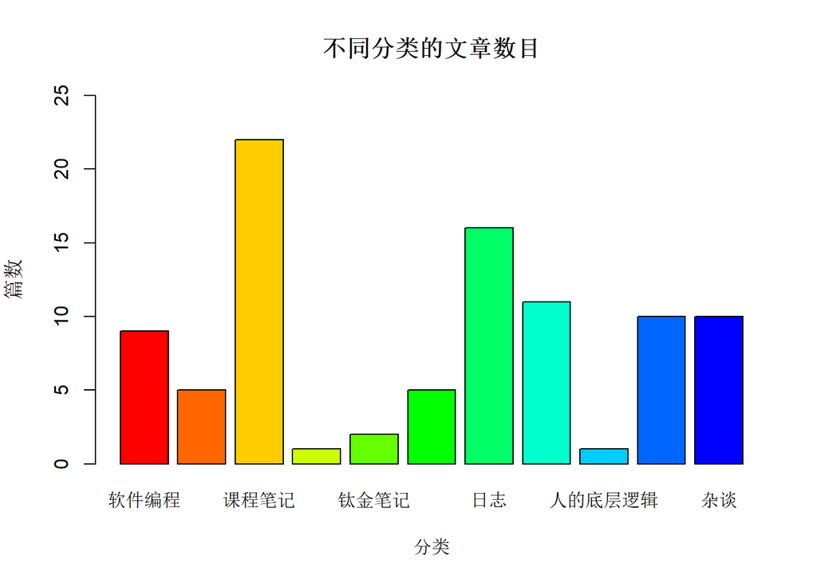

```r
zixu <- data.frame(
  categories=c("软件编程", "操作系统", "课程笔记", "语言学习", "钛金笔记", "随笔", "日志", "计划总结", "人的底层逻辑", "摄影思考", "杂谈"),
  count=c(9,5,22,1,2,5,16,11,1,10,10),
  like=c(8,7,9,7,5,8,10,7,6,9,8),
stringsAsFactors=FALSE)
colnames(zixu) <- c('分类','文章数量','喜欢度')
# knitr::kable(zixu) #使用knitr生成表格
barplot(zixu[,'文章数量'],names.arg=zixu[,'分类'],
        width=0.5,
        ylim=c(0,25),
        main = "不同分类的文章数目",
        xlab = '分类',
        ylab = '篇数',
        col =rainbow(15) )
```

[figure not shown]

```r
x <- rnorm(30, mean=0, sd=20)
hist(x, col=c('yellow'),
     main='正态随机数', xlab='', ylab='频数')
```

## Echarts4r绘图

### 折线图

```r
library(echarts4r)

df <- data.frame(
  x = seq(50),
  y = rnorm(50, 10, 3),
  z = rnorm(50, 11, 2),
  w = rnorm(50, 9, 2)
)

df |>
  e_charts(x) |>
  e_line(z) |>
  e_area(w) |>
  e_title("Line and area charts")
```

[interactive chart not shown]

```r
library(echarts4r)

df <- data.frame(
  x = seq(50),
  y = rnorm(50, 10, 3),
  z = rnorm(50, 11, 2),
  w = rnorm(50, 9, 2)
)

df |>
  e_charts(x) |>
  e_scatter(y, z) |>
  e_visual_map(z, scale = e_scale) |> # scale color
  e_legend(FALSE) # hide legend
```

[interactive chart not shown]

```r
df |>
  head(10) |>
  e_charts(x) |>
  e_effect_scatter(y, z) |>
  e_visual_map(z) |> # scale color
  e_legend(FALSE) # hide legend
```

[interactive chart not shown]

## rmarkdown简介及其与Hexo的联动

```yaml
output:
  html_document:
    toc: true
    toc_float:
      collapsed: false
      smooth_scroll: false
```

#### 选项卡式部分

> 使用`{.tabset .tabset-fade .tabset-pills}`来生成药丸风格的样式

```markdown
## Quarterly Results {.tabset}

### By Product

(tab content)

### By Region

(tab content)
```

#### 主题

默认[主题](https://www.datadreaming.org/post/r-markdown-theme-gallery/)有许多，但是比较呆板，可以安装几个附加的 R 包来实现更多的 R Markdown HTML 主题。例如 [`prettydoc`](https://yixuan.cos.name/prettydoc/)、[`rmdformat`](https://github.com/juba/rmdformats)、[`hrbrthemes`](https://github.com/hrbrmstr/hrbrthemes)、[`tufte`](https://github.com/rstudio/tufte) 和 [`tint`](http://dirk.eddelbuettel.com/code/tint.html)。

与本站风格比较匹配的是这个给名为`cayman`的主题（依赖prettydoc宏包），在front matter中修改下配置就好了（会失去对选项卡功能的支持）

```yaml
output:
    prettydoc::html_pretty:
    theme: cayman
    highlight: github
```

## hexo联动

其实一开始我是准备用yihui大佬的blogdown新建一个支持rmd的hugo站点来着，但是很浪费时间。又看到rmd生成的仅仅是一个html文件[^1]，没有外部依赖，便想到利用`<iframe>`标签嵌入到文章。

试验了一下，果然非常优雅，而且还很好的支持了echars4r的交互式绘图，棒棒哒！

```css
<iframe style="border-radius:12px" src="/pdf/R/可视乎·基本图表.html" width="100%" height="719.8" frameBorder="0" allowfullscreen="" allow="autoplay; clipboard-write; encrypted-media; fullscreen; picture-in-picture" loading="lazy"></iframe>
```

[^1]: R Markdown 生成没有外部依赖项的独立 HTML 文件，使用 URI 合并链接脚本、样式表、图像和视频的内容。